# Final Project

MGSC 310

Devin Keller & Dylan

```r
# Always print this out before your assignment
sessionInfo()
## R version 4.2.1 (2022-06-23)
## Platform: x86_64-apple-darwin17.0 (64-bit)
## Running under: macOS Catalina 10.15.7
##
## Matrix products: default
## BLAS:   /Library/Frameworks/R.framework/Versions/4.2/Resources/lib/libRblas.0.dylib
## LAPACK: /Library/Frameworks/R.framework/Versions/4.2/Resources/lib/libRlapack.dylib
##
## locale:
## [1] en_US.UTF-8/en_US.UTF-8/en_US.UTF-8/C/en_US.UTF-8/en_US.UTF-8
##
## attached base packages:
## [1] stats     graphics  grDevices utils     datasets  methods
## [7] base
##
## other attached packages:
## [1] knitr_1.40
##
## loaded via a namespace (and not attached):
##  [1] digest_0.6.29   R6_2.5.1        jsonlite_1.8.0  magrittr_2.0.3
##  [5] evaluate_0.16   stringi_1.7.8   cachem_1.0.6    rlang_1.0.5
##  [9] cli_3.3.0       rstudioapi_0.14 jquerylib_0.1.4 bslib_0.4.0
## [13] rmarkdown_2.16  tools_4.2.1     stringr_1.4.1   xfun_0.32
## [17] yaml_2.3.5      fastmap_1.1.0   compiler_4.2.1  htmltools_0.5.3
## [21] sass_0.4.2
getwd()
## [1] "/Users/dylanmcintosh/Documents/GitHub/PDM-Data-Analysis"
```

```r
# load all your libraries in this chunk
library('tidyverse')
library('forcats')
library('rsample')
library("readr")
library("dplyr")
library("purrr")
library('randomForest')
library('visNetwork')
library('sparkline')
library(partykit)
library(rpart.plot)
library(plotROC)
library(glmnet)
library(glmnetUtils)
library(ggridges)
library(randomForestExplainer)
library(ROCR)
# note, do not run install.packages() inside a code chunk. install them in the console outside of a code chunk.
```

# DATA CLEANING

Converts all variables into factors and splots the dataset into train and test sets

```r
lead_df <- read_csv("Lead_Tree.csv")

lead_df <- lead_df %>% as_tibble() %>%
  mutate(Converted = as.factor(Converted),
         Non_Work_Email = as.factor(Non_Work_Email),
         Title_Blank = as.factor(Title_Blank),
         Website_Blank = as.factor(Website_Blank))

# create a split with 75% of the data in the training set
lead_split <- initial_split(lead_df, prop = 0.75)
lead_train <- training(lead_split)
lead_test <- testing(lead_split)
```

# Summary Statistics

Shows count and proportions of each class of binary variables in the dataset

[figure not shown]

```r
summary(lead_df)
##  Non_Work_Email Title_Blank Website_Blank Converted
##  0:2089         0:1198      0:1339        0:2951
##  1:1466         1:2357      1:2216        1: 604

coeffMag <- data.frame(Variables=c("Non_Work_Email","Title_Blank","Website Blank", "Converted"),
                       count=c(2089,1198,1339,2951))

# Basic vertical barplot
Barchart <-ggplot(data=coeffMag, aes(x=Variables, y=count, fill=Variables))+
  geom_bar(stat="identity") + ggtitle("Count of True Values")

print(Barchart + coord_flip())
```

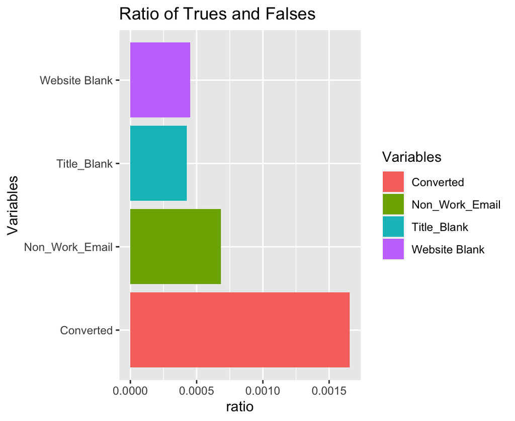

```r
coeffMag <- data.frame(Variables=c("Non_Work_Email","Title_Blank","Website Blank", "Converted"),
                       ratio=c(1/1466,1/2357,1/2216,1/604))

# Basic vertical barplot
Barchart <-ggplot(data=coeffMag, aes(x=Variables, y=ratio, fill=Variables))+
  geom_bar(stat="identity") + ggtitle("Ratio of Trues and Falses")

print(Barchart + coord_flip())
```

# Can we predict which leads are SPAM for lead scoring?

## Decision Tree

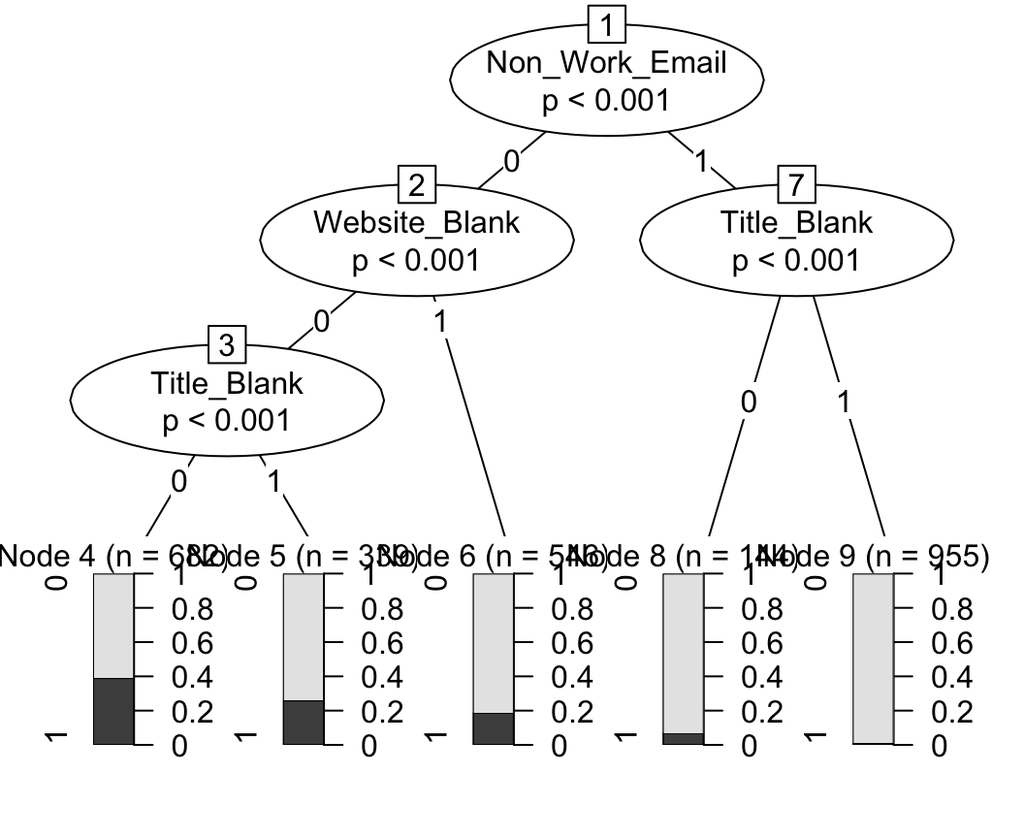

```r
# use the ctree_control parameters to adjust stopping criteria
lead_tree2 <- ctree(Converted ~ Non_Work_Email + Title_Blank + Website_Blank,
                       data = lead_train,
                   control = partykit::ctree_control(alpha=0.1,
                                                     minbucket = 50))
plot(lead_tree2)
```

```r
print(lead_tree2)
##
## Model formula:
## Converted ~ Non_Work_Email + Title_Blank + Website_Blank
##
## Fitted party:
## [1] root
## |   [2] Non_Work_Email in 0
## |   |   [3] Website_Blank in 0
## |   |   |   [4] Title_Blank in 0: 0 (n = 682, err = 39.0%)
## |   |   |   [5] Title_Blank in 1: 0 (n = 339, err = 26.0%)
## |   |   [6] Website_Blank in 1: 0 (n = 546, err = 18.7%)
## |   [7] Non_Work_Email in 1
## |   |   [8] Title_Blank in 0: 0 (n = 144, err = 6.9%)
## |   |   [9] Title_Blank in 1: 0 (n = 955, err = 1.2%)
##
## Number of inner nodes:    4
## Number of terminal nodes: 5
```

## Logistic Regression

```r
logit_fit <-  glm(Converted ~ Non_Work_Email + Title_Blank + Website_Blank,
                   family = binomial,
                   data = lead_train)

print(summary(logit_fit))
##
## Call:
## glm(formula = Converted ~ Non_Work_Email + Title_Blank + Website_Blank,
##     family = binomial, data = lead_train)
##
## Deviance Residuals:
##     Min       1Q   Median       3Q      Max
## -0.9910  -0.7807  -0.1867  -0.1867   2.8491
##
## Coefficients:
##                 Estimate Std. Error z value             Pr(>|z|)
## (Intercept)     -0.45579    0.07563  -6.026        0.00000000168 ***
## Non_Work_Email1 -2.48066    0.24553 -10.103 < 0.0000000000000002 ***
## Title_Blank1    -0.57631    0.12647  -4.557        0.00000519657 ***
## Website_Blank1  -0.52851    0.14439  -3.660             0.000252 ***
## ---
## Signif. codes:  0 '***' 0.001 '**' 0.01 '*' 0.05 '.' 0.1 ' ' 1
##
## (Dispersion parameter for binomial family taken to be 1)
##
##     Null deviance: 2504.7  on 2665  degrees of freedom
## Residual deviance: 2031.0  on 2662  degrees of freedom
## AIC: 2039
##
## Number of Fisher Scoring iterations: 6

print(exp(logit_fit$coefficients) - 1)
##     (Intercept) Non_Work_Email1    Title_Blank1  Website_Blank1
##      -0.3660527      -0.9163117      -0.4380296      -0.4105194
```

Successfully created logistic regression model and all p values seem appropriate meaning it is likely that all variables have significance and are valuable in predicting the output effectively. The exponentiated list of coefficients can be interpreted as a lead with a non-work email is 92% less likely to be a good lead as one with a work email.

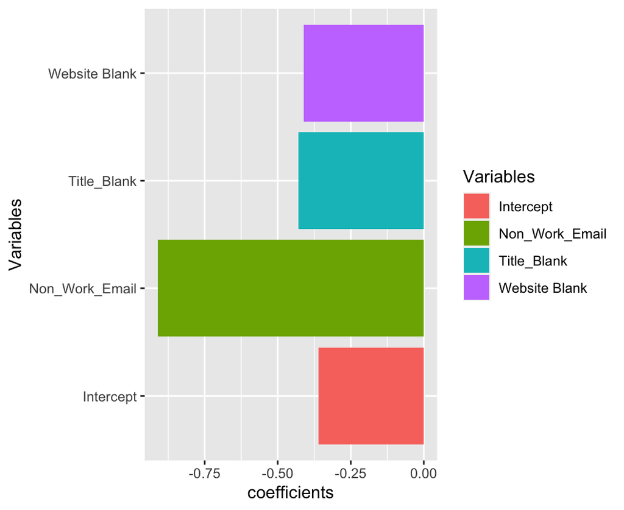

```r
coeffMag <- data.frame(Variables=c("Intercept","Non_Work_Email","Title_Blank","Website Blank"),
                       coefficients=c(-.36,-.91,-.43,-.41))

# Basic vertical barplot
Barchart <-ggplot(data=coeffMag, aes(x=Variables, y=coefficients, fill=Variables))+
  geom_bar(stat="identity")

Barchart + coord_flip()
```

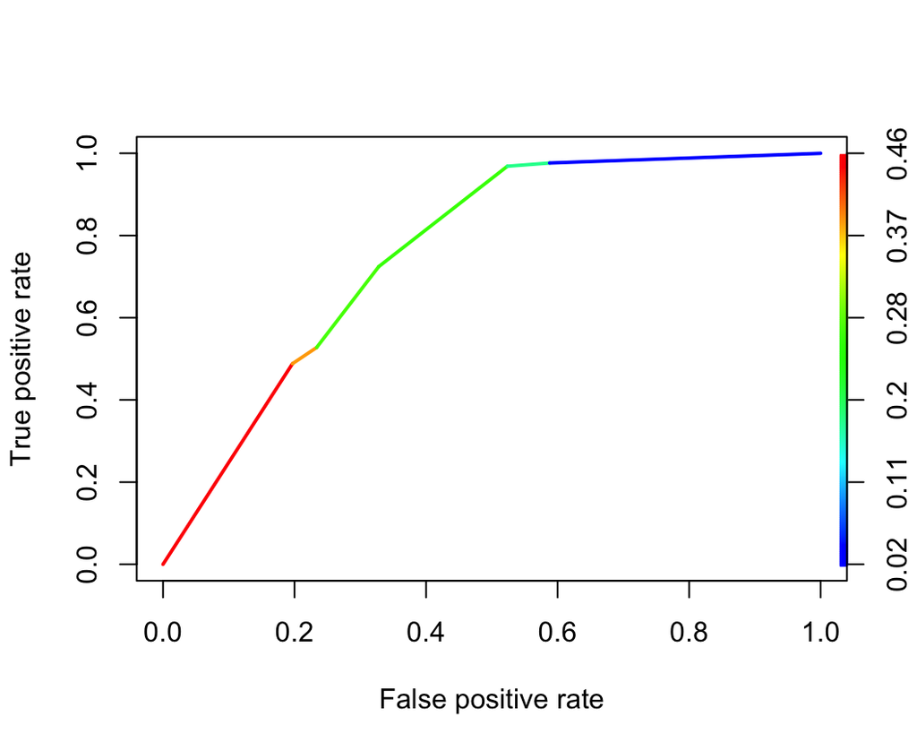

```r
scores_train <- predict(logit_fit,
                  type = "response",
                  data = lead_train)

scores_test <- predict(logit_fit,
                  type = "response",
                  data = lead_test)


pred = predict(logit_fit,lead_test,type="response")
pred = prediction(pred, lead_test$Converted)
roc = performance(pred,"tpr","fpr")
print(plot(roc, colorize = T, lwd = 2))
```

This AUC plot shows that the model performed pretty well and that a suitable probability cutoff would be 0.35 in order to maximize True postive rates and minimize false positive rates, best indicating which leads are convertable.

```r
auc = performance(pred, measure = "auc")
print(auc@y.values)
## [[1]]
## [1] 0.7611135

probs = predict(logit_fit, lead_test, type="response")
preds = rep("0", dim(lead_test)[1])
preds[probs > .35] = "1"

mean(preds == lead_test$Converted)
## [1] 0.7581552
```